# Tutorial: Hurricane dataset analysis

Vari ed eventuali

2024-11-28

```r
rm(list=ls())
#### some libraries
#### core functions (to be dropped when the pima package is ready)
library(jointest)
library(flipscores)
source("../R/filippo_utils.R")
source("../R/paolo_utils.R")
source("../R/pima.R")
source("../R/methods.R")
source("../R/spec_curve.R")
source("../R/pima_tree.R")
source("../R/utils_internal.R")
############

# results reporting
library(gtsummary)
library(tidyverse)
library(GGally)
library(knitr)
library(gridExtra)
library(corrplot)
# models
library(MASS)
# read STATA dataset
library(readstata13)
opts_chunk$set(echo=FALSE,
               cache=FALSE,
               prompt=FALSE,
               tidy=TRUE,
               comment=NA,
               message=FALSE,
               warning=FALSE)
hurricane<-read.dta13("../data/hurricanes_2015_01_09.dta")

#Original analysis from https://www.pnas.org/content/111/24/8782
#year: year of the hurricane
#masfem: 1 masculine - 11 feminine
#min: minimum of pression
#alldeaths: total deaths
#ndam: amount of damages normalized
#elapsedyrs: years since analysis
#masfem_mturk: femininity with mturk
#wind: highest wind speed
#ndam15: amount of damages normalized to the year 2015
```

# Hurricane

## Dataset pre processing

```r
hurricane$gender_mf <- as.factor(hurricane$gender_mf)
hurricane$category <- as.factor(hurricane$category)
levels(hurricane$gender_mf) <- c("Male", "Female")
hurricane[, c(1, 3, 4, 5, 7, 12, 13)] %>%
    tbl_summary(by = gender_mf) %>%
    add_p() %>%
    as_gt() %>%
    gt::as_latex()
```

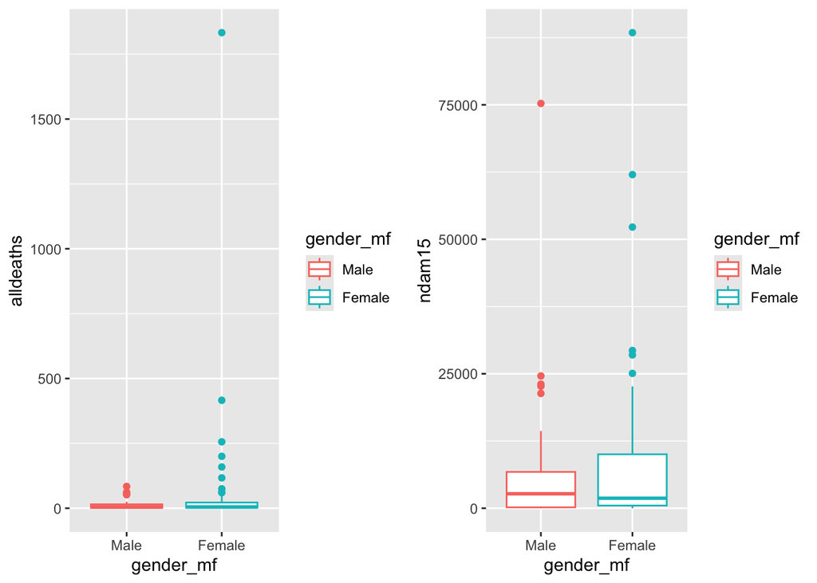

```r
# we consider only deaths

p1 <- ggplot(hurricane, aes(x = gender_mf, y = alldeaths, color = gender_mf)) + geom_boxplot()
p2 <- ggplot(hurricane, aes(x = gender_mf, y = ndam15, color = gender_mf)) + geom_boxplot()

grid.arrange(p1, p2, ncol = 2)
```

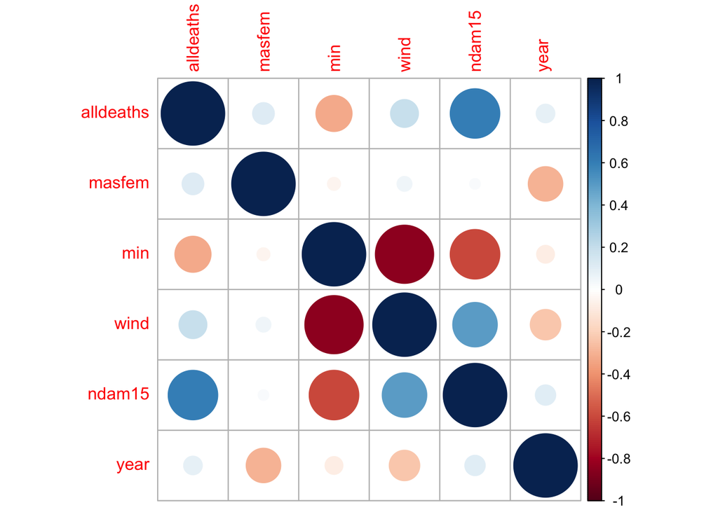

```r
# to export pdf('figure1.pdf',width = 10,height = 4) grid.arrange(p1,p2,ncol=2)
# dev.off()

# correlation plot
corrplot(cor(hurricane[, c("alldeaths", "masfem", "min", "wind", "ndam15", "year")]))
```

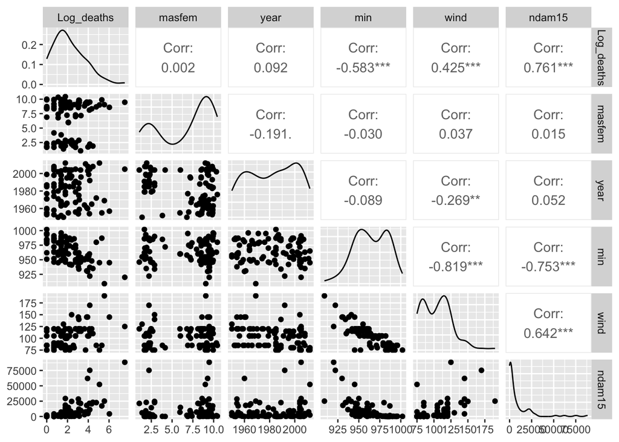

```r
hurricane$Log_deaths <- log(hurricane$alldeaths + 1)

pm <- ggpairs(hurricane, columns = c(14, 3, 1, 4, 12, 13), upper = list(continuous = wrap("cor",
    method = "spearman")))
pm
```

```r
# to export pdf('corr.pdf',width=8,height =5) pm dev.off()
```

## GLM Model

Quasi-Poisson model since the number of deaths right-skew distributed

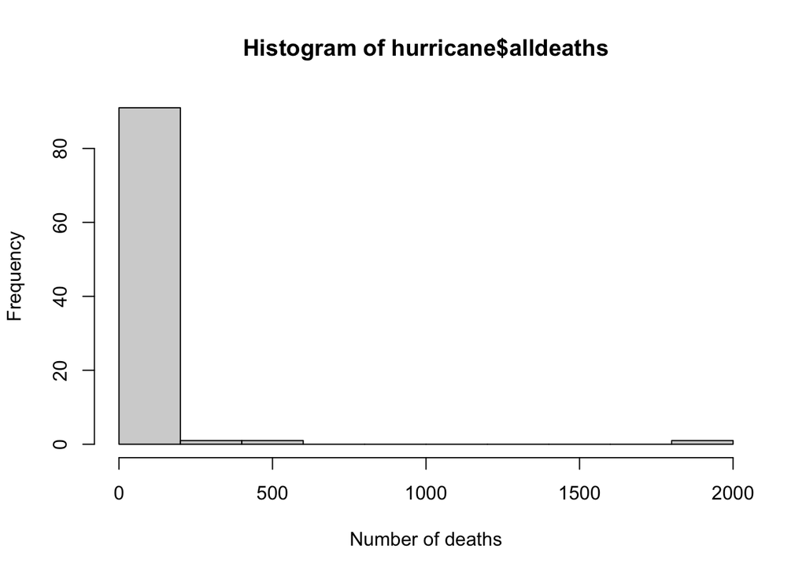

```r
hist(hurricane$alldeaths, ylab = "Frequency", xlab = "Number of deaths")
```

and Var(Y) >> E[Y] (3.80786^{4} > 44.1

Observational study design: - Outcome: Number of Death - Determinant: Femininity of the Hurricane Name - Confounders: Year, Min of pressure, Wind, Amount of damages normalized at 2015. We consider the following glm:

$$g(\mu)=\alpha+f_1(\mbox{mf})+f_2(\mbox{year})+f_3(\mbox{min})+f_4(\mbox{wind})+f_5(\mbox{ndam15})$$

where:

$$\mbox{alldeaths} \sim
quasiPoisson(\lambda=g^{-1}(X\beta),\phi)$$
where $\lambda$ is mean parameter and $\phi$ is estimated to deal with overdispersion (scale). Use set the $\log()$ as link function $g()$

Some considerations:  
- limited sample size: n=94  
- model with 5 predictors and 1 intercept

We consider a simple additive regression model like the follwing one:

$$g(\mu)=\alpha+\beta_1 mf+ \beta_2
year+\beta_3 min+\beta_4 wind+\beta_5 ndam15$$
The coefficient $\beta_1$ expresses the increase of the log-death due to a 1-point increase in the $mf$ variable. The results of a Poisson regression models are commonly expressed in terms of Incidence Rate Ratio (IRR) just by exponentiation of the coefficients. (IRR=$\exp(\beta_1)$).

### Theoretical model

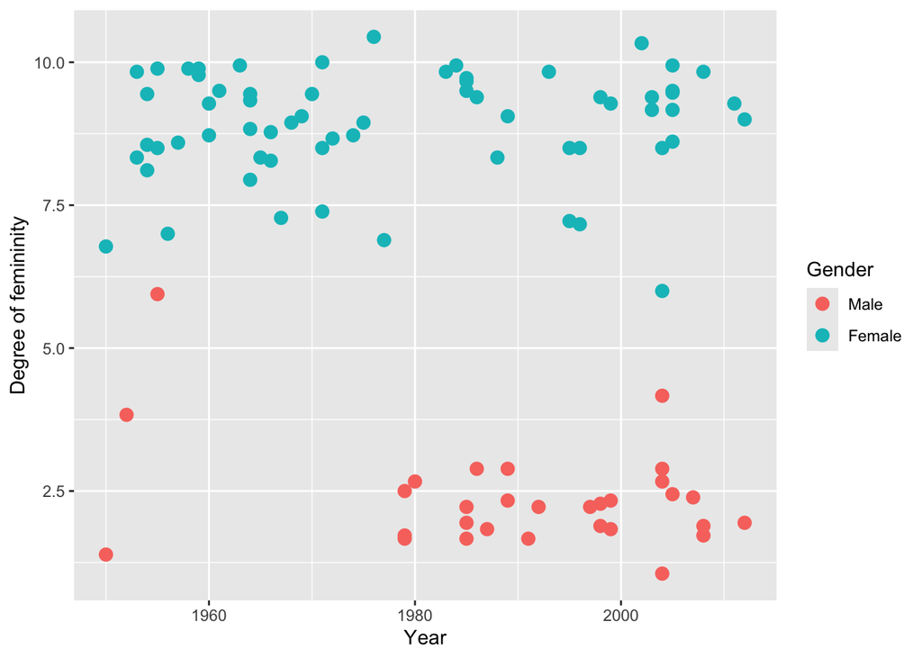

```r
ggplot(hurricane, aes(x = year, y = masfem, col = gender_mf)) + ylab("Degree of femininity") +
    geom_point(size = 3) + xlab("Year") + labs(col = "Gender")
```

## MULTIVERSE ANALYSIS

All the four confounders are continuous. In addition to the identity, we decide to explore for each confounders the following transformations:  
- Square Root ($\sqrt(x)$);  
- Log ($\sqrt(x)$);  
- Second order polynomial ($x+x^2$).

```r
########################################### possible specifications:
combinations_matrix = expand.grid(list(c("min", "sqrt(min)", "log(min)", "poly(min,2)"),
    c("wind", "sqrt(wind)", "log(wind)", "poly(wind,2)"), c("year", "sqrt(year)",
        "log(year)", "poly(year,2)"), c("ndam15", "sqrt(ndam15)", "log(ndam15)",
        "poly(ndam15,2)")))

combinations = apply(combinations_matrix, 1, paste, collapse = "+")
```

Then we combine all the transformations in $4^4=256$ specifications

```r
##################### one list of formulas for each comparison of interest:
formulas1 = sapply(combinations, function(cmb) paste0("alldeaths ~ masfem +", cmb))
mod1 = glm(as.formula(formulas1[1]), data = hurricane, family = quasipoisson())
mods1 = lapply(formulas1, function(frml) update(mod1, formula. = as.formula(frml)))
```

Using the function() we apply the PIMA procedure to the list of models inside the mods1 list.

```r
res1 = pima(mods1, tested_coeffs = c("masfem"), n_flips = 5000, score_type = "standardized",
    seed = 167)
names(res1)
```

```
[1] "Tspace"        "summary_table" "mods"          "info"
[5] "tested_coeffs"
```

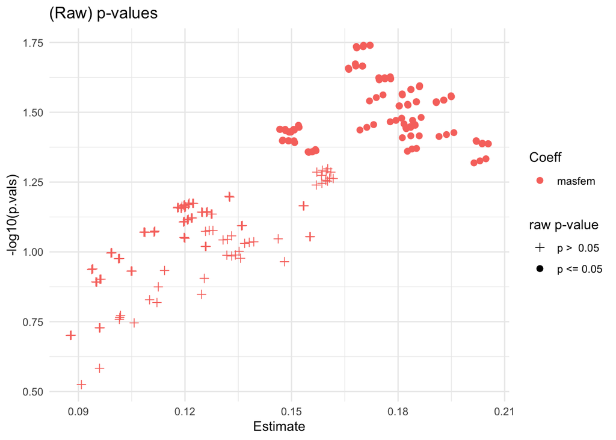

```r
plot.pima(res1, p.values = "raw")
```

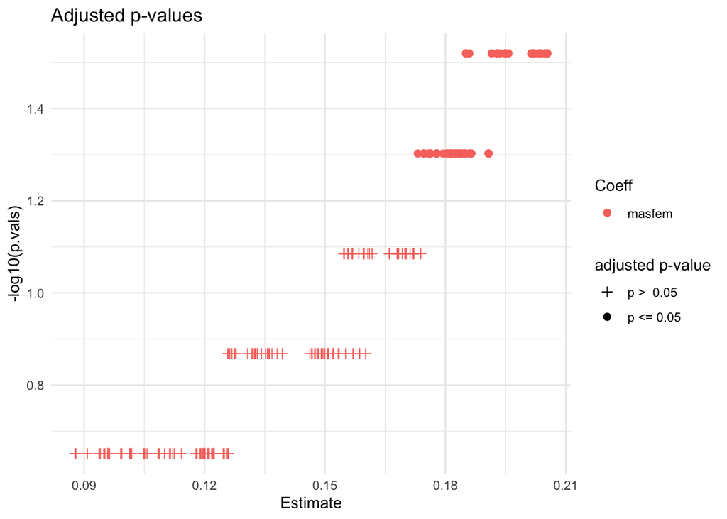

```r
plot.pima(res1, p.values = "adjusted")
```

The output is composed by:  
- Tspace: output table of sign_flip score testing  
- summary_table: overall results  
- mods: 256 models estimated (one for each specification)  
- info: specifications info (auxiliary object)

### Specification curve

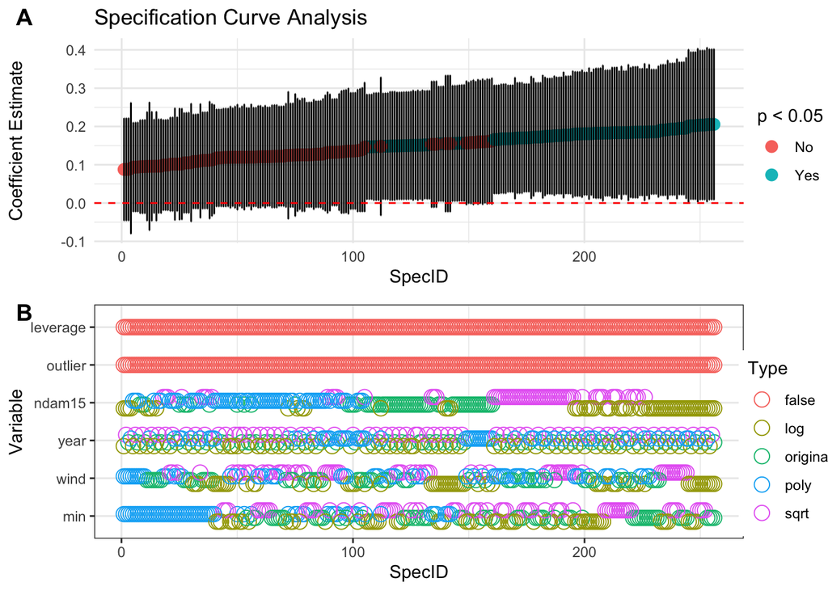

```r
####### ggplot2 e cowplot
library(ggplot2)
library(cowplot)
spec_curve1 <- spec_curve(res1, alpha = 0.05, p.values = "raw")
spec_curve1
```

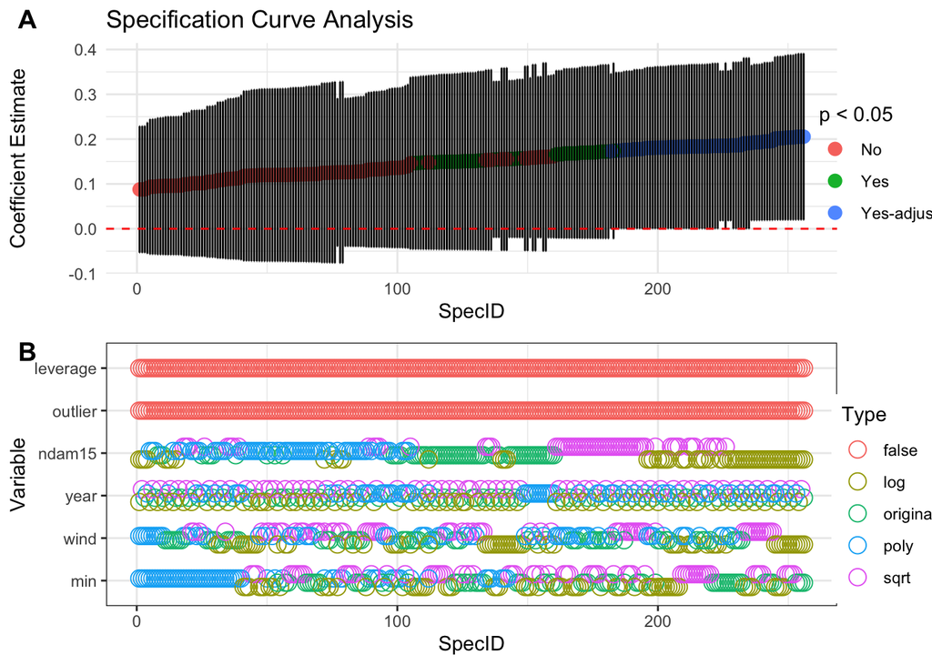

```r
spec_curve2 <- spec_curve(res1, alpha = 0.05, p.values = "adjusted")
spec_curve2
```

```r
t_stat_h0 <- apply(res1$Tspace, 1, max)
observed_t <- max(summary(res1)$Score)
2 * mean(abs(t_stat_h0) > abs(observed_t))
```

```
[1] 0.0528
```

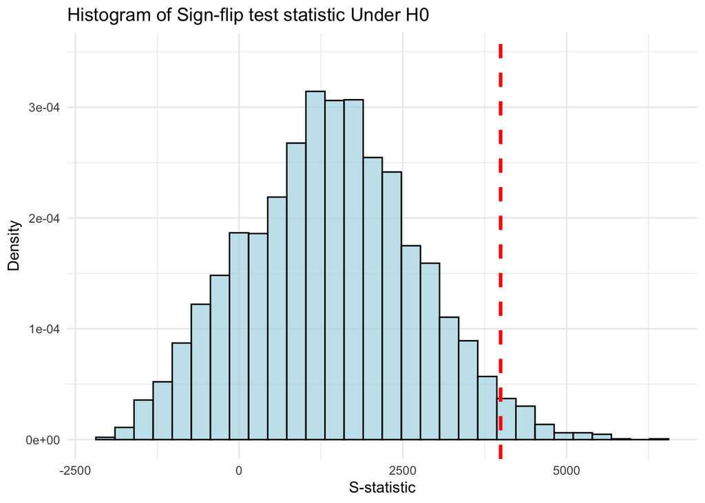

```r
ho_t <- ggplot(data = data.frame(t_stat_h0), aes(x = t_stat_h0)) + geom_histogram(aes(y = ..density..),
    fill = "lightblue", color = "black", alpha = 0.7) + geom_vline(aes(xintercept = observed_t),
    color = "red", linetype = "dashed", size = 1.2) + geom_text(aes(x = observed_t,
    y = 0.00035, label = paste("Observed S =", observed_t)), color = "red", angle = 90,
    vjust = -0.5, hjust = -0.5, size = 4) + labs(title = "Histogram of Sign-flip test statistic Under H0",
    x = "S-statistic", y = "Density") + theme_minimal()

# pdf('null_dist.pdf',height = 5,width = 8)
ho_t
```

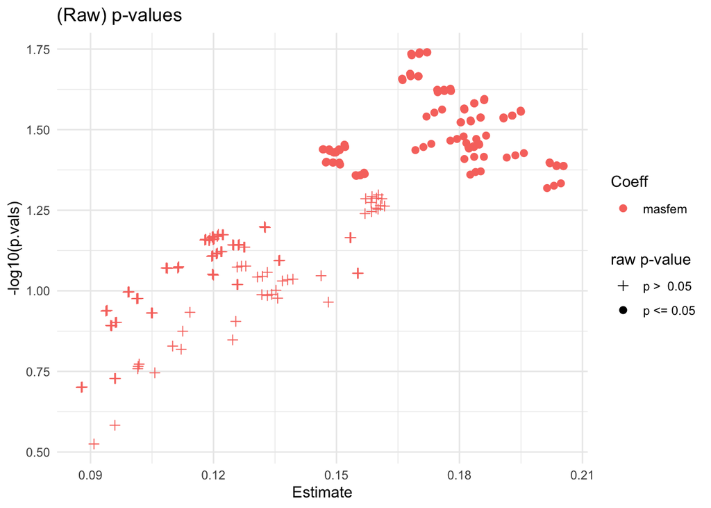

```r
# dev.off()


# adjusted pvalues
res1$summary_table$p.adj <- maxT.light(res1$Tspace, exp(seq(-8, 0, 0.5)))

p3 <- plot(res1)
# pdf('graph_raw.pdf',height = 5,width = 8)
p3
```

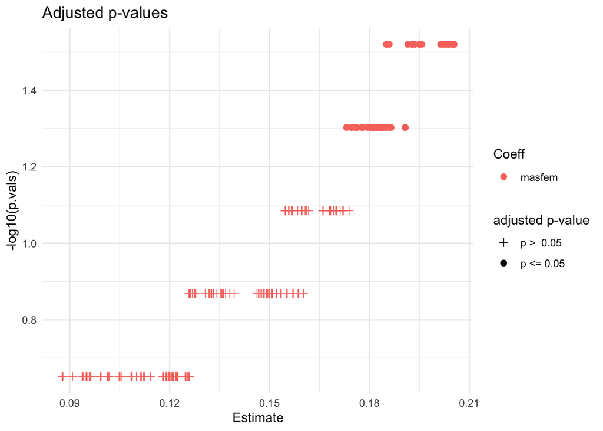

```r
# dev.off()

p4 <- plot(res1, p.values = "adjusted")
# pdf('graph_adj.pdf',height = 5,width = 8)
p4
```

```r
# dev.off()

sum(res1$summary_table$p.adj < 0.05)
```

```
[1] 74
```

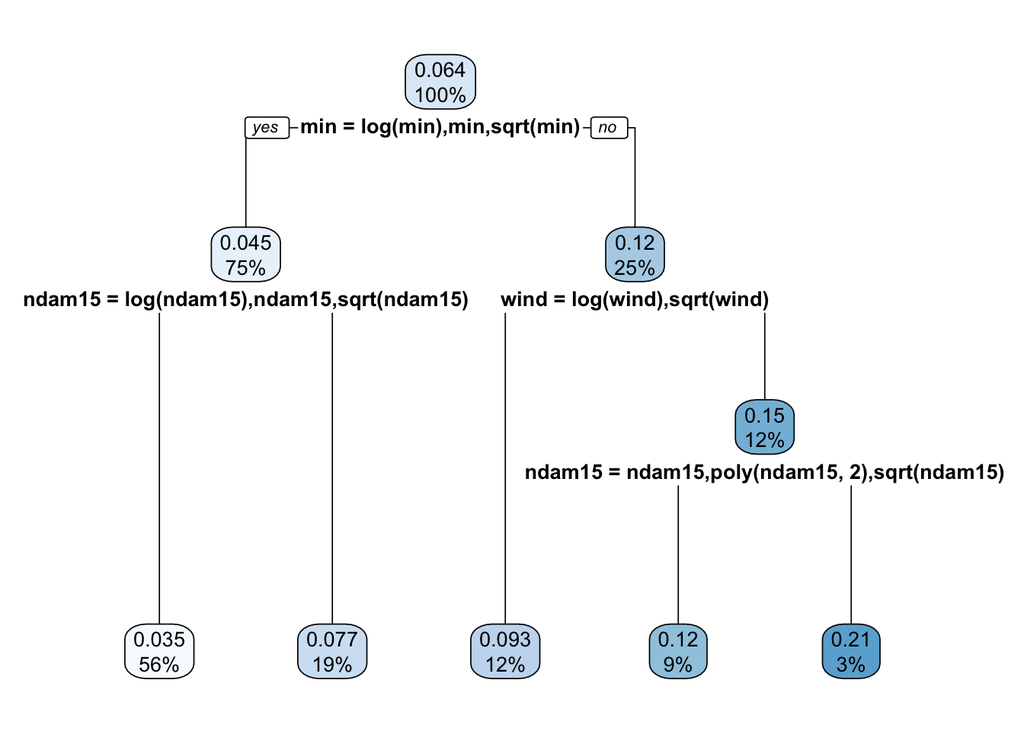

```r
library(rpart)
library(rpart.plot)
pima_tree(res = res1)  #raw
```

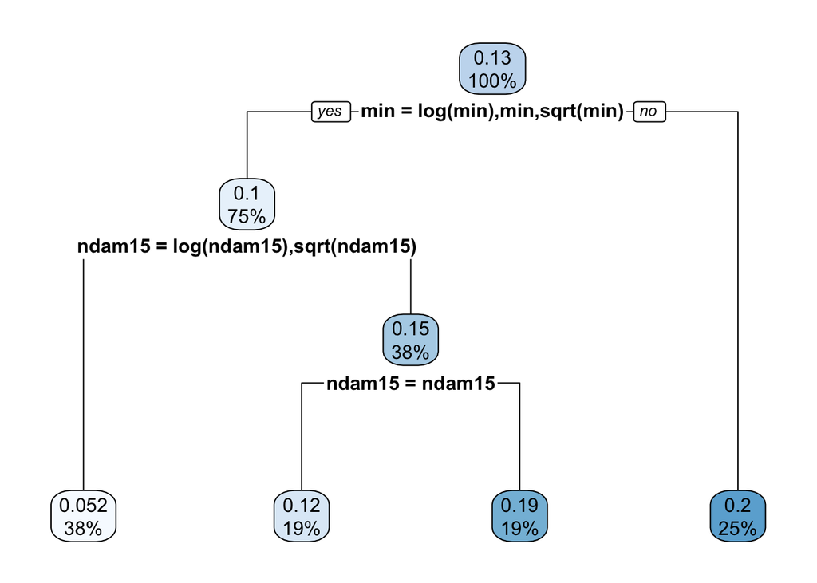

```r
pima_tree(res = res1, p.values = "adjusted")  #FWER adjusted pvalues
```

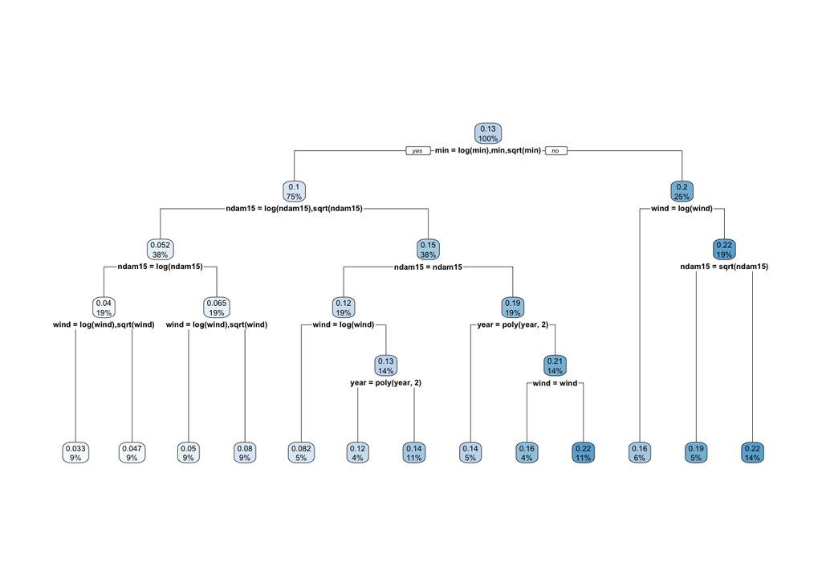

```r
pima_tree(res = res1, p.values = "adjusted", cp = 0.001)  #higher complexity
```

### Pick up a model

```r
sel_model <- which.min(res1$summary_table$p.adj)
summary(mods1[[sel_model]])
```

```
Call:
glm(formula = alldeaths ~ masfem + min + sqrt(wind) + year +
    log(ndam15), family = quasipoisson(), data = hurricane)

Coefficients:
             Estimate Std. Error t value Pr(>|t|)
(Intercept) 30.810199  50.670801   0.608   0.5447
masfem       0.195008   0.090753   2.149   0.0344 *
min         -0.044613   0.024698  -1.806   0.0743 .
sqrt(wind)  -0.244603   0.316342  -0.773   0.4415
year         0.005305   0.014151   0.375   0.7087
log(ndam15)  0.653161   0.211514   3.088   0.0027 **
---
Signif. codes:  0 '***' 0.001 '**' 0.01 '*' 0.05 '.' 0.1 ' ' 1

(Dispersion parameter for quasipoisson family taken to be 118.3996)

    Null deviance: 16673.2  on 93  degrees of freedom
Residual deviance:  4940.3  on 88  degrees of freedom
AIC: NA

Number of Fisher Scoring iterations: 6
```

```r
exp(summary(mods1[[sel_model]])$coef[2, 1])
```

```
[1] 1.21532
```

In the selected model the adjusted effect of the masfem variable is significant. 1-point increase in masfem variables implies an increase of the risk of death of 21.53 %